# Performing Literature Reviews with nails package

### Important authors

Sorted by the number of articles published and by the total number of citations.

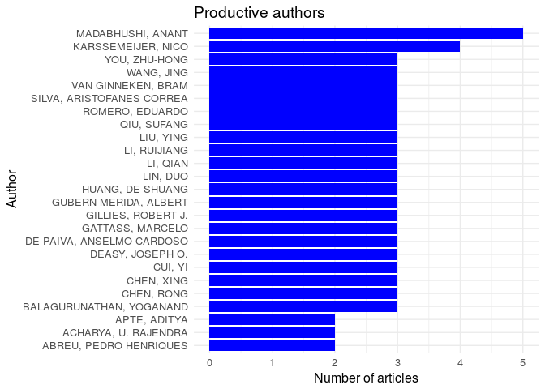

```r
# Get author network nodes, which contain the required information
author_network <- get_author_network(literature)
author_nodes <- author_network$author_nodes
# Change Id to AuthorFullName
names(author_nodes)[names(author_nodes) == "Id"] <- "AuthorFullName"

# Sort by number of articles by author
author_nodes <- author_nodes[with(author_nodes, order(-Freq)), ]
# Re-order factor levels
author_nodes <- transform(author_nodes, AuthorFullName = reorder(AuthorFullName,
    Freq))

ggplot(head(author_nodes, 25), aes(AuthorFullName, Freq)) + geom_bar(stat = "identity",
    fill = "blue") + coord_flip() + ggtitle("Productive authors") + xlab("Author") +
    ylab("Number of articles")
```

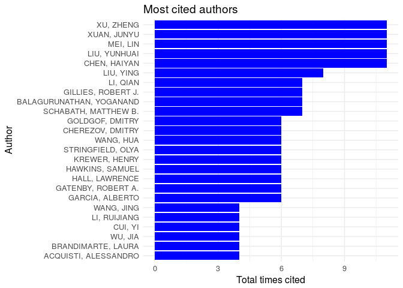

```r
# Reorder AuthorFullName factor according to TotalTimesCited (decreasing
# order)
author_nodes <- transform(author_nodes, AuthorFullName = reorder(AuthorFullName,
    TotalTimesCited))

# Sort by number of articles by author
author_nodes <- author_nodes[with(author_nodes, order(-TotalTimesCited)), ]

ggplot(head(author_nodes, 25), aes(AuthorFullName, TotalTimesCited)) + geom_bar(stat = "identity",
    fill = "blue") + coord_flip() + ggtitle("Most cited authors") + xlab("Author") +
    ylab("Total times cited")
```

### Important publications

Sorted by number of published articles in the dataset and by the total number of citations.

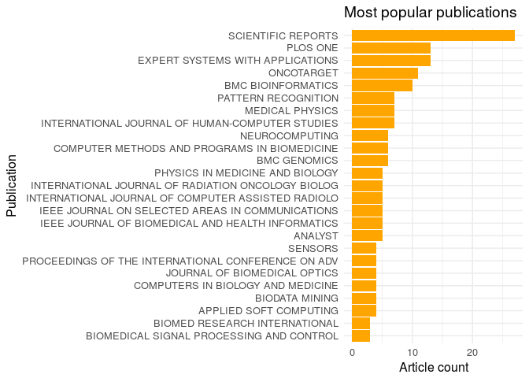

```r
# Calculate publication occurences
publications <- as.data.frame(table(literature$PublicationName))

# Fix names
names(publications) <- c("Publication", "Count")

# Trim publication name to maximum of 50 characters for displaying in plot
publications$Publication <- strtrim(publications$Publication, 50)

# Sort descending
publications <- publications[with(publications, order(-Count)), ]

# Reorder factor levels
publications <- transform(publications, Publication = reorder(Publication, Count))


# WHY???  literature <- merge(literature, citation_sums, by =
# 'PublicationName' )

ggplot(head(publications, 25), aes(Publication, Count)) + geom_bar(stat = "identity",
    fill = "orange") + coord_flip() + theme(legend.position = "none") + ggtitle("Most popular publications") +
    xlab("Publication") + ylab("Article count")
```

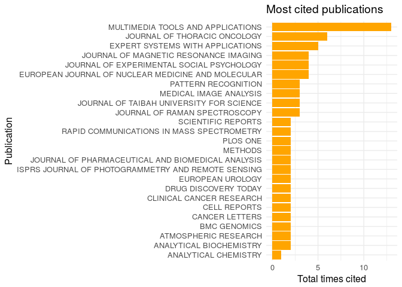

```r
# Calculating total citations for each publication.
citation_sums <- aggregate(literature$TimesCited, by = list(PublicationName = literature$PublicationName),
    FUN = sum, na.rm = T)

# Fix column names
names(citation_sums) <- c("PublicationName", "PublicationTotalCitations")

# Trim publication name to maximum of 50 characters for displaying in plot
citation_sums$PublicationName <- strtrim(citation_sums$PublicationName, 50)

# Sort descending and reorder factor levels accordingly
citation_sums <- citation_sums[with(citation_sums, order(-PublicationTotalCitations)),
    ]
citation_sums <- transform(citation_sums, PublicationName = reorder(PublicationName,
    PublicationTotalCitations))
ggplot(head(citation_sums, 25), aes(PublicationName, PublicationTotalCitations)) +
    geom_bar(stat = "identity", fill = "orange") + coord_flip() + theme(legend.position = "none") +
    ggtitle("Most cited publications") + xlab("Publication") + ylab("Total times cited")
```

### Important keywords

Sorted by the number of articles where the keyword is mentioned and by the total number of citations for the keyword.

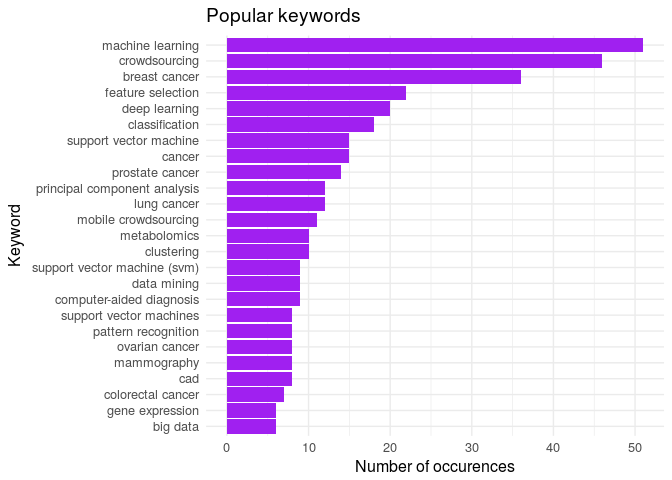

```r
# Calculating total citations for each keyword

literature_by_keywords <- arrange_by(literature, "AuthorKeywords")



# Sometimes AuthorKeywords column is empty.  Following if-else hack prevents
# crashing in those situations, either by using KeywordsPlus column or
# skipping keyword analysis.
if (nrow(literature_by_keywords) == 0) {
    cat("No keywords.")
} else {
    keyword_citation_sum <- aggregate(literature_by_keywords$TimesCited, by = list(AuthorKeywords = literature_by_keywords$AuthorKeywords),
        FUN = sum, na.rm = T)
    names(keyword_citation_sum) <- c("AuthorKeywords", "TotalTimesCited")

    keywords <- unlist(strsplit(literature$AuthorKeywords, ";"))
    keywords <- trim(keywords)
    keywords <- as.data.frame(table(keywords))
    names(keywords) <- c("AuthorKeywords", "Freq")

    keywords <- merge(keywords, keyword_citation_sum, by = "AuthorKeywords")
    keywords <- keywords[with(keywords, order(-Freq)), ]
    keywords <- transform(keywords, AuthorKeywords = reorder(AuthorKeywords,
        Freq))

    ggplot(head(keywords, 25), aes(AuthorKeywords, Freq)) + geom_bar(stat = "identity",
        fill = "purple") + coord_flip() + ggtitle("Popular keywords") + xlab("Keyword") +
        ylab("Number of occurences")
}
```

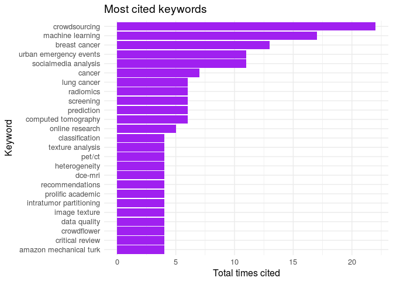

```r
if (nrow(literature_by_keywords) > 0) {
    keywords <- keywords[with(keywords, order(-TotalTimesCited)), ]
    keywords <- transform(keywords, AuthorKeywords = reorder(AuthorKeywords,
        TotalTimesCited))
    ggplot(head(keywords, 25), aes(AuthorKeywords, TotalTimesCited)) + geom_bar(stat = "identity",
        fill = "purple") + coord_flip() + ggtitle("Most cited keywords") + xlab("Keyword") +
        ylab("Total times cited")
}
```

### Important papers

The most important papers and other sources are identified below using three importance measures: 1) in-degree in the citation network, 2) citation count provided by Web of Science (only for papers included in the dataset), and 3) PageRank score in the citation network. The top 25 highest scoring papers are identified using these measures separately. The results are then combined and duplicates are removed. Results are sorted by in-degree, and ties are first broken by citation count and then by the PageRank.

When a [Digital Object Identifier (DOI)](http://www.doi.org/) is available, the full paper can be found using [Resolve DOI](https://dx.doi.org/) website.

```r
# Extract citation nodes
citation_network <- get_citation_network(literature)
citation_nodes <- citation_network$citation_nodes


# Extract the articles included in the data set and articles not included in
# the dataset
citations_lit <- citation_nodes[citation_nodes$Origin == "literature", ]
citations_ref <- citation_nodes[citation_nodes$Origin == "reference", ]

# Create article strings (document title, reference information and abstract
# separated by '|')
citations_lit$Article <- paste(toupper(citations_lit$DocumentTitle), " | ",
    citations_lit$FullReference, " | ", citations_lit$Abstract)
```

#### Included in the dataset

These papers were included in the 600 records downloaded from the Web of Science.

```r
# Sort citations_lit by TimesCited, decreasing
citations_lit <- citations_lit[with(citations_lit, order(-TimesCited)), ]
# Extract top 25
top_lit <- head(citations_lit, 25)
# Sort by InDegree, decreasing
citations_lit <- citations_lit[with(citations_lit, order(-InDegree)), ]
# Add to list of top 25 most cited papers
top_lit <- rbind(top_lit, head(citations_lit, 25))
# Sort by PageRank, decreasing
citations_lit <- citations_lit[with(citations_lit, order(-PageRank)), ]
# Add to list of most cited and highest InDegree papers
top_lit <- rbind(top_lit, head(citations_lit, 25))
# Remove duplicates
top_lit <- top_lit[!duplicated(top_lit[, "FullReference"]), ]
# Sort top_lit by InDegree, break ties by TimesCited, then PageRank.
top_lit <- top_lit[with(top_lit, order(-InDegree, -TimesCited, -PageRank)),
    ]
# Print list
knitr::kable(top_lit[, c("Article", "InDegree", "TimesCited", "PageRank")])
```

|  | Article | InDegree | TimesCited | PageRank |
| --- | --- | --- | --- | --- |
| 31810 | DIFFERENTIATION OF DIGESTIVE SYSTEM CANCERS BY USING SERUM PROTEIN-BASED SURFACE-ENHANCED RAMAN SPECTROSCOPY \| LIN J, 2017, J RAMAN SPECTROSC, V48, P16, DOI 10.1002/JRS.4982 \| The aim of this study … | 2 | 3 | 4.14e-05 |
| 4109 | PREDICTING MALIGNANT NODULES FROM SCREENING CT SCANS \| HAWKINS S, 2016, J THORAC ONCOL, V11, P2120, DOI 10.1016/J.JTHO.2016.07.002 \| Objectives: The aim of this study was to determine whether quanti… | 1 | 6 | 4.09e-05 |
| 46310 | INTRATUMOR PARTITIONING AND TEXTURE ANALYSIS OF DYNAMIC CONTRAST-ENHANCED (DCE)-MRI IDENTIFIES RELEVANT TUMOR SUBREGIONS TO PREDICT PATHOLOGICAL RESPONSE OF BREAST CANCER TO NEOADJUVANT CHEMOTHERAPY \… | 1 | 4 | 4.01e-05 |
| 35110 | MULTI-CROP CONVOLUTIONAL NEURAL NETWORKS FOR LUNG NODULE MALIGNANCY SUSPICIOUSNESS CLASSIFICATION \| SHEN W, 2017, PATTERN RECOGN, V61, P663, DOI 10.1016/J.PATCOG.2016.05.029 \| We investigate the pro… | 1 | 2 | 4.04e-05 |
| 34710 | LARGE SCALE DEEP LEARNING FOR COMPUTER AIDED DETECTION OF MAMMOGRAPHIC LESIONS \| KOOI T, 2017, MED IMAGE ANAL, V35, P303, DOI 10.1016/J.MEDIA.2016.07.007 \| Recent advances in machine learning yielde… | 1 | 2 | 4.01e-05 |
| 16647 | CORRELATION OF LIPIDOMIC COMPOSITION OF CELL LINES AND TISSUES OF BREAST CANCER PATIENTS USING HYDROPHILIC INTERACTION LIQUID CHROMATOGRAPHY/ELECTROSPRAY IONIZATION MASS SPECTROMETRY AND MULTIVARIATE … | 1 | 1 | 4.04e-05 |
| 8125 | ESTIMATING PERSONALIZED DIAGNOSTIC RULES DEPENDING ON INDIVIDUALIZED CHARACTERISTICS \| LIU Y, 2017, STAT MED, V36, P1099, DOI 10.1002/SIM.7182 \| There is an increasing demand for personalization of … | 1 | 1 | 4.01e-05 |
| 34310 | DIFFERENTIATING TUMOR HETEROGENEITY IN FORMALIN-FIXED PARAFFIN-EMBEDDED (FFPE) PROSTATE ADENOCARCINOMA TISSUES USING PRINCIPAL COMPONENT ANALYSIS OF MATRIX-ASSISTED LASER DESORPTION/IONIZATION IMAGING… | 1 | 1 | 4.00e-05 |
| 9812 | DISSECTING TARGET TOXIC TISSUE AND TISSUE SPECIFIC RESPONSES OF IRINOTECAN IN RATS USING METABOLOMICS APPROACH \| YAO Y, 2017, FRONT PHARMACOL, V8, P, DOI 10.3389/FPHAR.2017.00122 \| As an anticancer … | 1 | 1 | 3.99e-05 |
| 55310 | CROWDSOURCING BASED SOCIAL MEDIA DATA ANALYSIS OF URBAN EMERGENCY EVENTS \| XU Z, 2017, MULTIMED TOOLS APPL, V76, P11567, DOI 10.1007/S11042-015-2731-1 \| An urban emergency event requires an immediat… | 0 | 11 | 3.93e-05 |
| 34610 | CHARACTERIZATION OF PET/CT IMAGES USING TEXTURE ANALYSIS: THE PAST, THE PRESENTA… ANY FUTURE? \| HATT M, 2017, EUR J NUCL MED MOL I, V44, P151, DOI 10.1007/S00259-016-3427-0 \| After seminal papers ov… | 0 | 4 | 3.93e-05 |
| 5659 | BEYOND THE TURK: ALTERNATIVE PLATFORMS FOR CROWDSOURCING BEHAVIORAL RESEARCH \| PEER E, 2017, J EXP SOC PSYCHOL, V70, P153, DOI 10.1016/J.JESP.2017.01.006 \| The success of Amazon Mechanical Turk (MTu… | 0 | 4 | 3.93e-05 |
| 45010 | MODELLING THE CYTOTOXIC ACTIVITY OF PYRAZOLO-TRIAZOLE HYBRIDS USING DESCRIPTORS CALCULATED FROM THE OPEN SOURCE TOOL PADEL-DESCRIPTOR \| AMIN SA, 2016, J TAIBAH UNIV SCI, V10, P896, DOI 10.1016/J.JTUS… | 0 | 3 | 3.93e-05 |
| 18816 | DESIGN OF EFFICIENT COMPUTATIONAL WORKFLOWS FOR IN SILICO DRUG REPURPOSING \| VANHAELEN Q, 2017, DRUG DISCOV TODAY, V22, P210, DOI 10.1016/J.DRUDIS.2016.09.019 \| Here, we provide a comprehensive over… | 0 | 2 | 3.93e-05 |
| 2465 | PAN-CANCER IMMUNOGENOMIC ANALYSES REVEAL GENOTYPE-IMMUNOPHENOTYPE RELATIONSHIPS AND PREDICTORS OF RESPONSE TO CHECKPOINT BLOCKADE \| CHAROENTONG P, 2017, CELL REP, V18, P248, DOI 10.1016/J.CELREP.2016… | 0 | 2 | 3.93e-05 |
| 3531 | FUZZY CLUSTER BASED NEURAL NETWORK CLASSIFIER FOR CLASSIFYING BREAST TUMORS IN ULTRASOUND IMAGES \| SINGH BK, 2016, EXPERT SYST APPL, V66, P114, DOI 10.1016/J.ESWA.2016.09.006 \| The performance of su… | 0 | 2 | 3.93e-05 |
| 36910 | CHEMICAL COMPOSITION AND SOURCE APPORTIONMENT OF PM2.5 DURING CHINESE SPRING FESTIVAL AT XINXIANG, A HEAVILY POLLUTED CITY IN NORTH CHINA: FIREWORKS AND HEALTH RISKS \| FENG J, 2016, ATMOS RES, V182, … | 0 | 2 | 3.93e-05 |
| 41110 | FEATURE SELECTION METHODS FOR BIG DATA BIOINFORMATICS: A SURVEY FROM THE SEARCH PERSPECTIVE \| WANG L, 2016, METHODS, V111, P21, DOI 10.1016/J.YMETH.2016.08.014 \| This paper surveys main principles o… | 0 | 2 | 3.93e-05 |
| 4333 | NANOSCOPIC TUMOR TISSUE DISTRIBUTION OF PLATINUM AFTER INTRAPERITONEAL ADMINISTRATION IN A XENOGRAFT MODEL OF OVARIAN CANCER \| CARLIER C, 2016, J PHARMACEUT BIOMED, V131, P256, DOI 10.1016/J.JPBA.201… | 0 | 2 | 3.93e-05 |
| 4729 | BIG DATA AND MACHINE LEARNING IN RADIATION ONCOLOGY: STATE OF THE ART AND FUTURE PROSPECTS \| BIBAULT J, 2016, CANCER LETT, V382, P110, DOI 10.1016/J.CANLET.2016.05.033 \| Precision medicine relies on… | 0 | 2 | 3.93e-05 |
| 48410 | A COMPUTATIONAL APPROACH FOR DETECTING PIGMENTED SKIN LESIONS IN MACROSCOPIC IMAGES \| OLIVEIRA RB, 2016, EXPERT SYST APPL, V61, P53, DOI 10.1016/J.ESWA.2016.05.017 \| Skin cancer is considered one of… | 0 | 2 | 3.93e-05 |
| 49010 | IDENTIFICATION AND COMPARATIVE ORIDONIN METABOLISM IN DIFFERENT SPECIES LIVER MICROSOMES BY USING UPLC-TRIPLE-TOF-MS/MS AND PCA \| MA Y, 2016, ANAL BIOCHEM, V511, P61, DOI 10.1016/J.AB.2016.08.004 \| … | 0 | 2 | 3.93e-05 |
| 54410 | GAMIFYING COLLECTIVE HUMAN BEHAVIOR WITH GAMEFUL DIGITAL RHETORIC \| SAKAMOTO M, 2017, MULTIMED TOOLS APPL, V76, P12539, DOI 10.1007/S11042-016-3665-Y \| This paper presents a design framework called … | 0 | 2 | 3.93e-05 |
| 55110 | RULE-GUIDED HUMAN CLASSIFICATION OF VOLUNTEERED GEOGRAPHIC INFORMATION \| ALI AL, 2017, ISPRS J PHOTOGRAMM, V127, P3, DOI 10.1016/J.ISPRSJPRS.2016.06.003 \| During the last decade, web technologies an… | 0 | 2 | 3.93e-05 |
| 36010 | ICAGES: INTEGRATED CANCER GENOME SCORE FOR COMPREHENSIVELY PRIORITIZING DRIVER GENES IN PERSONAL CANCER GENOMES \| DONG C, 2016, GENOME MED, V8, P, DOI 10.1186/S13073-016-0390-0 \| Cancer results from… | 0 | 1 | 3.93e-05 |
| 2912 | SUBGROUPS OF CASTRATION-RESISTANT PROSTATE CANCER BONE METASTASES DEFINED THROUGH AN INVERSE RELATIONSHIP BETWEEN ANDROGEN RECEPTOR ACTIVITY AND IMMUNE RESPONSE \| YLITALO EB, 2017, EUR UROL, V71, P77… | 0 | 1 | 3.93e-05 |
| 5851 | UNTARGETED LC-HRMS-BASED METABOLOMICS FOR SEARCHING NEW BIOMARKERS OF PANCREATIC DUCTAL ADENOCARCINOMA: A PILOT STUDY \| RIOS PS, 2017, SLAS DISCOV, V22, P348, DOI 10.1177/1087057116671490 \| Pancreat… | 0 | 1 | 3.93e-05 |
| 7739 | WESTERN DIETARY PATTERN INCREASES, AND PRUDENT DIETARY PATTERN DECREASES, RISK OF INCIDENT DIVERTICULITIS IN A PROSPECTIVE COHORT STUDY \| STRATE LL, 2017, GASTROENTEROLOGY, V152, P1023, DOI 10.1053/J… | 0 | 1 | 3.93e-05 |
| 8033 | A SURVEY ON SEMI-SUPERVISED FEATURE SELECTION METHODS \| SHEIKHPOUR R, 2017, PATTERN RECOGN, V64, P141, DOI 10.1016/J.PATCOG.2016.11.003 \| Feature selection is a significant task in data mining and m… | 0 | 1 | 3.93e-05 |
| 9551 | CURE-SMOTE ALGORITHM AND HYBRID ALGORITHM FOR FEATURE SELECTION AND PARAMETER OPTIMIZATION BASED ON RANDOM FORESTS \| MA L, 2017, BMC BIOINFORMATICS, V18, P, DOI 10.1186/S12859-017-1578-Z \| Backgroun… | 0 | 0 | 3.93e-05 |
| 49110 | LIPIDOMIC PROFILING OF LUNG PLEURAL EFFUSION IDENTIFIES UNIQUE METABOTYPE FOR EGFR MUTANTS IN NON-SMALL CELL LUNG CANCER \| HO YS, 2016, SCI REP-UK, V6, P, DOI 10.1038/SREP35110 \| Cytology and histol… | 0 | 0 | 3.93e-05 |

#### Not included in the dataset

These papers and other references were not among the 600 records downloaded from the Web of Science.

```r
# Sort citations_ref by InDegree, decreasing
citations_ref <- citations_ref[with(citations_ref, order(-InDegree)), ]
# Extract top 25
top_ref <- head(citations_ref, 25)
# Sort by PageRank, decreasing
citations_ref <- citations_ref[with(citations_ref, order(-PageRank)), ]
# Add to list of highes in degree papers (references)
top_ref <- rbind(top_ref, head(citations_ref, 25))
# Remove duplicates
top_ref <- top_ref[!duplicated(top_ref[, "FullReference"]), ]
# Sort by InDegree, break ties by PageRank
top_ref <- top_ref[with(top_ref, order(-InDegree, -PageRank)), ]
# Print results
knitr::kable(top_ref[, c("FullReference", "InDegree", "PageRank")])
```

|  | FullReference | InDegree | PageRank |
| --- | --- | --- | --- |
| 1461 | BREIMAN L, 2001, MACH LEARN, V45, P5, DOI 10.1023/A:1010933404324 | 46 | 7.83e-05 |
| 214 | CHIH-CHUNG CHANG, 2011, ACM TRANSACTIONS ON INTELLIGENT SYSTEMS AND TECHNOLOGY, V2, DOI 10.1145/1961189.1961199 | 39 | 7.34e-05 |
| 291 | CORTES C, 1995, MACH LEARN, V20, P273, DOI 10.1023/A:1022627411411 | 32 | 6.44e-05 |
| 2756 | 2 | 22 | 5.83e-05 |
| 457 | HARALICK RM, 1973, IEEE T SYST MAN CYB, VSMC3, P610, DOI 10.1109/TSMC.1973.4309314 | 17 | 5.15e-05 |
| 3353 | GOLUB TR, 1999, SCIENCE, V286, P531, DOI 10.1126/SCIENCE.286.5439.531 | 17 | 4.99e-05 |
| 1386 | GUYON I, 2002, MACH LEARN, V46, P389, DOI 10.1023/A:1012487302797 | 16 | 5.06e-05 |
| 1950 | LECUN Y, 2015, NATURE, V521, P436, DOI 10.1038/NATURE14539 | 16 | 4.99e-05 |
| 61 | PENG HC, 2005, IEEE T PATTERN ANAL, V27, P1226, DOI 10.1109/TPAMI.2005.159 | 16 | 4.93e-05 |
| 2435 | HALL M., 2009, SIGKDD EXPLORATIONS, V11, P10, DOI 10.1145/1656274.1656278 | 15 | 5.59e-05 |
| 4406 | BREIMAN L, 1996, MACH LEARN, V24, P123, DOI 10.1023/A:1018054314350 | 15 | 5.00e-05 |
| 3367 | SAEYS Y, 2007, BIOINFORMATICS, V23, P2507, DOI 10.1093/BIOINFORMATICS/BTM344 | 15 | 4.83e-05 |
| 2798 | TIBSHIRANI R, 1996, J ROY STAT SOC B MET, V58, P267 | 13 | 5.00e-05 |
| 129 | HANAHAN D, 2011, CELL, V144, P646, DOI 10.1016/J.CELL.2011.02.013 | 12 | 4.95e-05 |
| 8006 | KOUROU K, 2015, COMPUT STRUCT BIOTEC, V13, P8, DOI 10.1016/J.CSBJ.2014.11.005 | 11 | 4.78e-05 |
| 364 | CHAWLA NV, 2002, J ARTIF INTELL RES, V16, P321 | 11 | 4.71e-05 |
| 900 | PEDREGOSA F, 2011, J MACH LEARN RES, V12, P2825 | 11 | 4.67e-05 |
| 3598 | GUYON I., 2003, JOURNAL OF MACHINE LEARNING RESEARCH, V3, P1157, DOI 10.1162/153244303322753616 | 11 | 4.60e-05 |
| 2597 | SIEGEL RL, 2015, CA-CANCER J CLIN, V65, P5, DOI 10.3322/CAAC.21254 | 10 | 4.70e-05 |
| 1949 | LECUN Y, 1998, P IEEE, V86, P2278, DOI 10.1109/5.726791 | 10 | 4.69e-05 |
| 2207 | SRIVASTAVA N, 2014, J MACH LEARN RES, V15, P1929 | 10 | 4.63e-05 |
| 882 | HINTON GE, 2006, SCIENCE, V313, P504, DOI 10.1126/SCIENCE.1127647 | 10 | 4.55e-05 |
| 2668 | OJALA T, 2002, IEEE T PATTERN ANAL, V24, P971, DOI 10.1109/TPAMI.2002.1017623 | 10 | 4.54e-05 |
| 3841 | JEMAL A, 2011, CA-CANCER J CLIN, V61, P2011, DOI 10.3322/CAAC.20107 | 9 | 4.89e-05 |
| 2891 | TORRE LA, 2015, CA-CANCER J CLIN, V65, P87, DOI 10.3322/CAAC.21262 | 9 | 4.73e-05 |
| 1498 | VAPNIK V.N., 1998, STAT LEARNING THEORY | 9 | 4.48e-05 |
| 1659 | HUANG ZW, 2003, INT J CANCER, V107, P1047, DOI 10.1002/IJC.11500 | 8 | 4.78e-05 |
| 1997 | GURCAN M. N., 2009, BIOMEDICAL ENG IEEE, V2, P147, DOI 10.1109/RBME.2009.2034865 | 8 | 4.70e-05 |
| 1212 | ARMATO SG, 2011, MED PHYS, V38, P915, DOI 10.1118/1.3528204 | 7 | 4.67e-05 |
| 9701 | FENG SY, 2011, SCI CHINA LIFE SCI, V54, P828, DOI 10.1007/S11427-011-4212-8 | 4 | 4.67e-05 |

### Most referenced publications

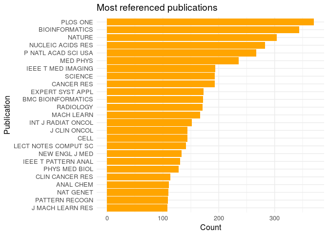

```r
references <- unlist(strsplit(literature$CitedReferences, ";"))

get_publication <- function(x) {
    publication <- "Not found"
    try(publication <- unlist(strsplit(x, ","))[[3]], silent = TRUE)
    return(publication)
}

refPublications <- sapply(references, get_publication)
refPublications <- sapply(refPublications, trim)
refPublications <- refPublications[refPublications != "Not found"]
refPublications <- as.data.frame(table(refPublications))
names(refPublications) <- c("Publication", "Count")
refPublications <- refPublications[with(refPublications, order(-Count)), ]

refPublications <- transform(refPublications, Publication = reorder(Publication,
    Count))

ggplot(head(refPublications, 25), aes(Publication, Count)) + geom_bar(stat = "identity",
    fill = "orange") + coord_flip() + theme(legend.position = "none") + ggtitle("Most referenced publications") +
    xlab("Publication") + ylab("Count")
```

### Topic Model

[Topic modeling](https://en.wikipedia.org/wiki/Topic_model) is a type of statistical text mining method for discovering common “topics” that occur in a collection of documents. A topic modeling algorithm essentially looks through the abstracts included in the datasets for clusters of co-occurring of words and groups them together by a process of similarity.

The following columns describe each topic detected using [LDA topic modeling](http://blog.echen.me/2011/08/22/introduction-to-latent-dirichlet-allocation/) by listing the ten most characteristic words in each topic.

You can specify K, the number of topics, when calling *build_topicmodel_from_literature(literature, K)*. If left empty, *stm::searchK* function is used to estimate the number of topics. For performance reasons the search range is between 4 and 12. The number of topics is estimated using the [structural topic model library](https://cran.r-project.org/web/packages/stm/index.html) semantic coherence diagnostic values. Raw values are available in output file as kqualityvalues.csv and can be interpreted with [stm documentation](https://cran.r-project.org/web/packages/stm/vignettes/stmVignette.pdf) if necessary (see section 3.4).

The analysis below creates the topic model using the convenience functions and then prints out ten most descriptive words for each discovered topic. See [topicmodels](https://cran.r-project.org/web/packages/topicmodels/index.html) documentation on the TopicModel-class on other information and instructions and documentation on *build_topicmodel_from_literature* how to use the rest of the data the convenience function procides.

```r
topicmodel <- build_topicmodel_from_literature(literature)

topickeywords <- topicmodels::terms(topicmodel$fit, 10)
tw <- data.frame(topickeywords)
colnames(tw) <- gsub("X", "Topic ", colnames(tw))
knitr::kable(tw, col.names = colnames(tw))
```

| Topic.1 | Topic.2 | Topic.3 | Topic.4 | Topic.5 |
| --- | --- | --- | --- | --- |
| analysi | crowdsourc | cancer | imag | model |
| patient | data | gene | cancer | method |
| studi | inform | predict | breast | data |
| compon | research | cell | detect | featur |
| sampl | studi | identifi | method | learn |
| princip | collect | express | system | algorithm |
| cancer | task | analysi | base | classif |
| risk | design | tumor | featur | machin |
| valid | system | studi | segment | perform |
| signific | provid | treatment | result | select |